# GeneSetCluster 2.0

### 1.5.8 Loading the IPA functional annotations

Using GeneSetCluster to load Functional annotations is possible by adding Functional_annotations to type. Specify in the loader that these are functional annotations and set the Pvalue cutoff accordingly. Using default settings Canonical pathways are exported with -log10 transformed Pvalues, meaning the larger is more significant, while functional annotations are exported with untransformed pvalues.

```r
################################################
#-------IPA on Functional_annotations----------#
################################################


functional.files <- IPA.files[grep("Functional", IPA.files)]

IPA.Functional.object1 <- LoadGeneSets(file_location = functional.files,
                                 groupnames= c("Functional.KO", "Functional.WT"),
                                 P.cutoff = 0.05,
                                 Mol.cutoff = 5,
                                 Source = "IPA",
                                 type = "Functional_annotations",
                                 structure = "SYMBOL",
                                 seperator = ",")
```

```
## [=========================================================]
```

```
## [<<<<            LoadGeneSets START                  >>>>>]
```

```
## Loading data from C:/Users/asier.ortega/AppData/Local/R/win-library/4.2/GeneSetCluster/extdata/MM10.IPA.KO.uGvsMac.Functional_annotations.xls
```

```
## Loading data from C:/Users/asier.ortega/AppData/Local/R/win-library/4.2/GeneSetCluster/extdata/MM10.IPA.WT.uGvsMac.Functional_annotations.xls
```

```
## Loading IPA Functional_annotations
```

```
## [<<<<<               LoadGeneSets END               >>>>>>]
```

```
## [=========================================================]
```

```
## [You may want to process CombineGeneSets next.            ]
```

```
## [or merge objects using MergeObjects                     ]
```

```
## [or select certain types from objects using ManageGeneSets]
```

Plot Overlap of functions labels using VennDiagram we can see the overlap between the different labels in the IPA functional output. Many functional annotations labels are shared while the Canonical Pathways showed different results.

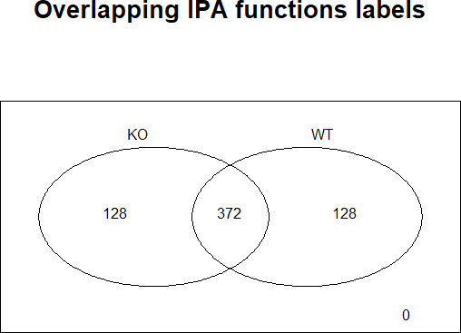

```r
VennDiagram(n_groups = 2,
               Group1 = as.character(IPA.Functional.object1@Data$Functional.KO$Pathways),
               Group2 =as.character(IPA.Functional.object1@Data$Functional.WT$Pathways),
               names_groups = c("KO", "WT"),
               main = "Overlapping IPA functions labels",legend = F, percentage = F )
```

IPA functional meta here we can see the overlap between the different labels in the IPA functional output. They should reflect the experiments accordingly.

```r
ShowExperimentdata(Object =IPA.Functional.object1 )
```

```
##                 Groupnames Length
## Experiment_1 Functional.KO    500
## Experiment_2 Functional.WT    500
##                                                                                                                            file_location
## Experiment_1 C:/Users/asier.ortega/AppData/Local/R/win-library/4.2/GeneSetCluster/extdata/MM10.IPA.KO.uGvsMac.Functional_annotations.xls
## Experiment_2 C:/Users/asier.ortega/AppData/Local/R/win-library/4.2/GeneSetCluster/extdata/MM10.IPA.WT.uGvsMac.Functional_annotations.xls
```

```r
ShowMeta(Object = IPA.Functional.object1 )
```

```
##              source                   type structure     organism        Groups
## Experiment_1    IPA Functional_annotations    SYMBOL org.Mm.eg.db Functional.KO
## Experiment_2    IPA Functional_annotations    SYMBOL org.Mm.eg.db Functional.WT
##              seperator Data cluster.method highlight order.group loaded
## Experiment_1         , List             NA        NA          NA   Auto
## Experiment_2         , List             NA        NA          NA   Auto
##                display mol.signature
## Experiment_1 Condensed           All
## Experiment_2 Condensed           All
```

### 1.5.9 IPA Combining and clustering functional Gene-Sets

This functional object works the same as the rest.

```r
IPA.Functional.object2 <- CombineGeneSets(Object = IPA.Functional.object1,
                                          display = "Expanded", threads = 8)
```

```
## [=========================================================]
```

```
## [<<<<            CombineGeneSets START               >>>>>]
```

```
## transforming all genes to upper case, make sure this doesnt change the data
```

```
## raw data has 1769 genes
```

```
## Transformed data has 1769 genes
```

```
## Combining experiments
```

```
## preparing expanded display
```

```
## calulating RR
```

```
## Parallelizing processes, 8 cores have been selected.
```

```
## [<<<<<             CombineGeneSets END              >>>>>>]
```

```
## [=========================================================]
```

```
## [You may want to process ClusterGeneSets next.            ]
```

```r
OptimalGeneSets(Object = IPA.Functional.object2, method = "Gap", cluster_method = "kmeans", main="IPA.Functional.object2",max_cluster = 15)
```

```
## [=========================================================]
```

```
## [<<<<            OptimalGeneSets START               >>>>>]
```

```
## Finding optimal number of clusters
```

```
## Clustering method =  kmeans
```

```
## Optimizing method =  gap
```

```
## [<<<<<             OptimalGeneSets END              >>>>>>]
```

```
## [=========================================================]
```

```
## [You may want to process ClusterGeneSets next.            ]
```

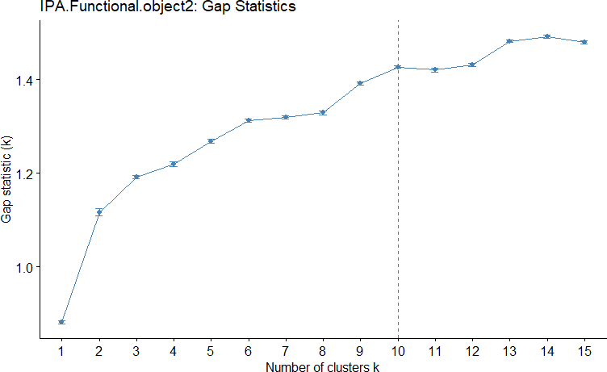

```r
IPA.Functional.object3 <- ClusterGeneSets(Object = IPA.Functional.object2,
                               clusters = 8,
                               method = "kmeans")
```

```
## [=========================================================]
```

```
## [<<<<            ClusterGeneSets START               >>>>>]
```

```
## Using all Gene sets
```

```
## Running kmeans
```

```
## Ordering pathway clusters
```

```
## [<<<<<             ClusterGeneSets END              >>>>>>]
```

```
## [=========================================================]
```

```
## [You may want to process HighlightGeneSets next.            ]
```

```
## [You may want to plot the results using PlotGeneSets next. ]
```

Plot The IPA functional RR. Plotting the different Pathways shows that it works the same to investigate the different clusters.

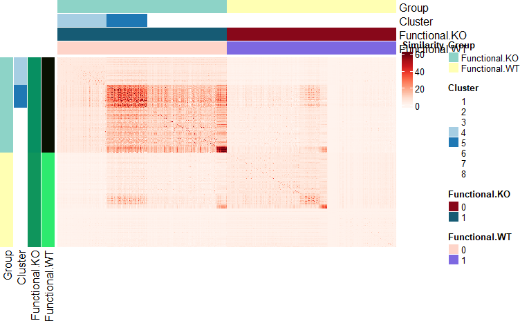

### 1.5.10 Merging the canonical pathways and functional annotations

```r
Ipa.merged.object1 <- MergeObjects(Object.1 =IPA.object1,
                                   Object.2 = IPA.Functional.object1)
```

```
## [=========================================================]
```

```
## [<<<<            MergeObjects START                 >>>>>]
```

```
## merging data sets
```

```
## [<<<<<               MergeObjects END              >>>>>>]
```

```
## [=========================================================]
```

```r
ShowExperimentdata(Object =Ipa.merged.object1 )
```

```
##                 Groupnames Length
## Experiment_1  Canonical.KO     61
## Experiment_2  Canonical.WT    284
## Experiment_3 Functional.KO    500
## Experiment_4 Functional.WT    500
##                                                                                                                            file_location
## Experiment_1     C:/Users/asier.ortega/AppData/Local/R/win-library/4.2/GeneSetCluster/extdata/MM10.IPA.KO.uGvsMac.Canonical_pathways.xls
## Experiment_2     C:/Users/asier.ortega/AppData/Local/R/win-library/4.2/GeneSetCluster/extdata/MM10.IPA.WT.uGvsMac.Canonical_pathways.xls
## Experiment_3 C:/Users/asier.ortega/AppData/Local/R/win-library/4.2/GeneSetCluster/extdata/MM10.IPA.KO.uGvsMac.Functional_annotations.xls
## Experiment_4 C:/Users/asier.ortega/AppData/Local/R/win-library/4.2/GeneSetCluster/extdata/MM10.IPA.WT.uGvsMac.Functional_annotations.xls
```

```r
ShowMeta(Object = Ipa.merged.object1 )
```

```
##              source                   type structure     organism        Groups
## Experiment_1    IPA     Canonical_Pathways    SYMBOL org.Mm.eg.db  Canonical.KO
## Experiment_2    IPA     Canonical_Pathways    SYMBOL org.Mm.eg.db  Canonical.WT
## Experiment_3    IPA Functional_annotations    SYMBOL org.Mm.eg.db Functional.KO
## Experiment_4    IPA Functional_annotations    SYMBOL org.Mm.eg.db Functional.WT
##              seperator Data cluster.method highlight order.group loaded
## Experiment_1         , List             NA        NA          NA   Auto
## Experiment_2         , List             NA        NA          NA   Auto
## Experiment_3         , List             NA        NA          NA   Auto
## Experiment_4         , List             NA        NA          NA   Auto
##                display mol.signature
## Experiment_1 Condensed           All
## Experiment_2 Condensed           All
## Experiment_3 Condensed           All
## Experiment_4 Condensed           All
```

Combine and cluster merged data following merging the pipeline combines and clusters the results. Of note here is of course the time it takes growths exponentially with larger datasets, so the merged data takes longer than the seperate data sets.

```r
Ipa.merged.object2 <- CombineGeneSets(Object = Ipa.merged.object1,
                                      display="Expanded", threads = 8)
```

```
## [=========================================================]
```

```
## [<<<<            CombineGeneSets START               >>>>>]
```

```
## transforming all genes to upper case, make sure this doesnt change the data
```

```
## raw data has 1772 genes
```

```
## Transformed data has 1772 genes
```

```
## Combining experiments
```

```
## preparing expanded display
```

```
## calulating RR
```

```
## Parallelizing processes, 8 cores have been selected.
```

```
## [<<<<<             CombineGeneSets END              >>>>>>]
```

```
## [=========================================================]
```

```
## [You may want to process ClusterGeneSets next.            ]
```

```r
Ipa.merged.object3 <- ClusterGeneSets(Object = Ipa.merged.object2,
                                          clusters = 14,
                                          method = "kmeans")
```

```
## [=========================================================]
```

```
## [<<<<            ClusterGeneSets START               >>>>>]
```

```
## Using all Gene sets
```

```
## Running kmeans
```

```
## Ordering pathway clusters
```

```
## [<<<<<             ClusterGeneSets END              >>>>>>]
```

```
## [=========================================================]
```

```
## [You may want to process HighlightGeneSets next.            ]
```

```
## [You may want to plot the results using PlotGeneSets next. ]
```

Merged Data in Object3 now the data sets are merged and compared. These are completely normal PathwayObjects now. So we can also highlight the object same as we done before.

```r
Ipa.merged.object3.highlight <- HighlightGeneSets(Object = Ipa.merged.object3, highligt.genes = Redox.genes, name = "Ros")
```

```
## [=========================================================]
```

```
## [<<<<<             HighlightGeneSets start            >>>>>>]
```

```
## make sure that the structure of the highlight.genes is the same as the data
```

```
## transforming all highligt.genes to upper case, make sure this doesnt change the data
```

```
## raw data has 377 highligt.genes
```

```
## Transformed data has 377 highligt.genes
```

```
## Calculating overlap between pathways and highlight genes
```

```
## [<<<<<             HighlightGeneSets END              >>>>>>]
```

```
## [=========================================================]
```

### 1.5.11 Plot The IPA merged RR

In the heatmap with the expanded display clearly shows the difference between the different clusters.

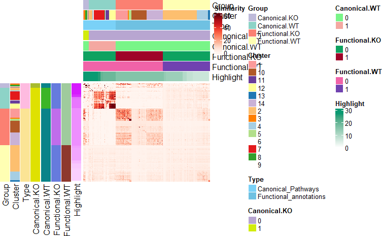

### 1.5.12 Export the combined pathways and RR

Exporting the files is done using the WriteGeneSets. It writes it in the folder assigned to file_location and it takes the name of Name and writes it into a CSV file with seperation of “;”, to make it readable by Excel.

```r
WriteGeneSets(Object = Ipa.merged.object3.highlight, file_location = getwd(), name = "Ipa.merged.object3.highlight", write = "Both")
```

Creating object with custom table when data wasnt run in GREAT or IPA the pipeline can still be used. In fact it doesnt neccesary need to be proper pathways. The thing the code needs is a group, a name, and name content. Plus some meta info. It is possible to simulate a dataset.

Creating random pathway data simulation starts with generating a random data set. Assign the names as Pathway_1 etc. With the genes inside just being Gene_1 to Gene_200.

```r
Test.object <- matrix(data = NA, nrow = 50, ncol = 3)
colnames(Test.object) <- c("Pathways", "Genes", "Group")
Test.object[,"Pathways"] <- paste("Pathway", 1:nrow(Test.object), sep = "_")
Test.object[1:25,"Group"] <- "Group1"
Test.object[26:50,"Group"] <- "Group2"


#Create a random amount of genes per pathway
random.gene <- function()
{
  genenames <- paste("Gene", 1:200, sep = "_")#this gives 200 gene names
  genes <- round(runif(n = runif(n = 1,min =  7,max = 20), min = 1, max = 200), digits = 0)#This gives between 7 and 20 random whole numbers
  genes <- unique(genes)#remove duplicate numbers
  genes <- genenames[genes]#get random genesnames
  return(genes)
}

for(i in 1:nrow(Test.object))
{
  Test.object[i, "Genes"] <- paste(random.gene(), collapse=",")#Collapse the genes into a string
}

head(Test.object)
```

```
##      Pathways
## [1,] "Pathway_1"
## [2,] "Pathway_2"
## [3,] "Pathway_3"
## [4,] "Pathway_4"
## [5,] "Pathway_5"
## [6,] "Pathway_6"
##      Genes
## [1,] "Gene_53,Gene_127,Gene_71,Gene_37,Gene_104,Gene_5,Gene_18,Gene_61,Gene_195,Gene_185,Gene_130,Gene_91,Gene_70,Gene_158,Gene_84,Gene_44,Gene_190"
## [2,] "Gene_144,Gene_143,Gene_126,Gene_191,Gene_138,Gene_42,Gene_21,Gene_80,Gene_5,Gene_155"
## [3,] "Gene_38,Gene_93,Gene_3,Gene_153,Gene_36,Gene_44,Gene_189,Gene_119,Gene_89,Gene_76"
## [4,] "Gene_42,Gene_100,Gene_49,Gene_65,Gene_124,Gene_179,Gene_121,Gene_162,Gene_107,Gene_83,Gene_27,Gene_48,Gene_137"
## [5,] "Gene_56,Gene_86,Gene_149,Gene_10,Gene_122,Gene_43,Gene_146,Gene_136,Gene_35"
## [6,] "Gene_120,Gene_177,Gene_145,Gene_116,Gene_72,Gene_200,Gene_171,Gene_85,Gene_196"
##      Group
## [1,] "Group1"
## [2,] "Group1"
## [3,] "Group1"
## [4,] "Group1"
## [5,] "Group1"
## [6,] "Group1"
```

### 1.5.13 Creating object with custom table

This simulated dataset is then inputted into the ObjectCreator to generate a proper PathwayObject.

```r
Test.object1 <- ObjectCreator(Pathways = Test.object[,1],
                              Molecules = Test.object[,2],
                              Groups = Test.object[,3],
                              Source = "Random",
                              Type = "Random",
                              structure = "SYMBOL",organism ="Org.HS.eg.db",
                              sep = ",")#neccesay to seperate the different genes for combinations.
```

```
## [=========================================================]
```

```
## [<<<<            ObjectCreator START                 >>>>>]
```

```
## [<<<<<               ObjectCreator END              >>>>>>]
```

```
## [=========================================================]
```

```
## [You may want to process CombineGeneSets next.            ]
```

```
## [or merge objects using MergeObjects                     ]
```

```
## [or select certain types from objects using ManageGeneSets]
```

```r
ShowExperimentdata(Object = Test.object1)
```

```
##              Groupnames Length file_location
## Experiment_1     Group1     25            NA
## Experiment_2     Group2     25            NA
```

```r
ShowMeta(Object = Test.object1)
```

```
##              source   type structure     organism seperator Data cluster.method
## Experiment_1 Random Random    SYMBOL Org.HS.eg.db         ,   DF             NA
## Experiment_2 Random Random    SYMBOL Org.HS.eg.db         ,   DF             NA
##              highlight order.group loaded   display mol.signature
## Experiment_1        NA          NA Manual Condensed           All
## Experiment_2        NA          NA Manual Condensed           All
```

Creating Combine and clustering custom object the combining and clustering works exactly the same as autoloaded objects.

```r
Test.object2 <- CombineGeneSets(Object = Test.object1, threads = 8)
```

```
## [=========================================================]
```

```
## [<<<<            CombineGeneSets START               >>>>>]
```

```
## transforming all genes to upper case, make sure this doesnt change the data
```

```
## raw data has 198 genes
```

```
## Transformed data has 198 genes
```

```
## Combining experiments
```

```
## preparing condensed display
```

```
## calulating RR
```

```
## Parallelizing processes, 8 cores have been selected.
```

```
## [<<<<<             CombineGeneSets END              >>>>>>]
```

```
## [=========================================================]
```

```
## [You may want to process ClusterGeneSets next.            ]
```

```r
Test.object3 <- ClusterGeneSets(Object = Test.object2,
                                                clusters = 4,
                                                method = "kmeans",
                                                order = "group")
```

```
## [=========================================================]
```

```
## [<<<<            ClusterGeneSets START               >>>>>]
```

```
## Using all Gene sets
```

```
## Running kmeans
```

```
## Ordering pathway clusters
```

```
## [<<<<<             ClusterGeneSets END              >>>>>>]
```

```
## [=========================================================]
```

```
## [You may want to process HighlightGeneSets next.            ]
```

```
## [You may want to plot the results using PlotGeneSets next. ]
```

Plotting custom Object the plotting works the same as any other object3. Note there are few clusters visible because the data is random.

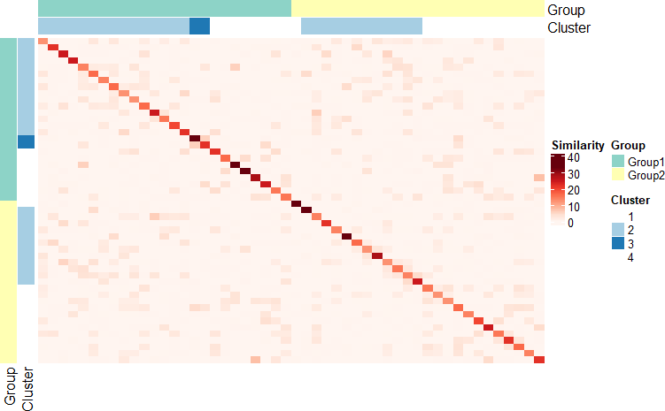

```r
PlotGeneSets(Object = Test.object3, fontsize =5,
            legend = T,
            annotation.mol=F,
            doORA = F,
            wordcloud = F,
            main="Random genes", RR.max = 50)
```